# Homework 06

## Question 1: Compare KNN and logistic regression

Use breast-cancer.csv, which contains 569 cases from the [Wisconsin Diagnostic Breast Cancer dataset](https://archive.ics.uci.edu/dataset/17/breast%2Bcancer%2Bwisconsin%2Bdiagnostic). Predict `y` (1 for malignant and 0 for benign) using `mean_radius`, `mean_texture`, and `mean_smoothness`.

Set a random seed and randomly split the observations into 70% training and 30% test data. Use the same split for every model. Standardize the predictors using the training means and standard deviations, and apply the same transformations to the test data.

Fit ordinary logistic regression with an intercept and no penalty, and KNN with Euclidean distance, equal neighbor weights, and

$$k\in\{5,15,25,35,45\}.$$

Using the estimated probabilities for `y = 1` on the test data, plot all six ROC curves in one figure and report their AUC values. Which of the six fitted models do you prefer? Give a brief justification based on your results.

```r
library(tidyverse)
df = read_csv("C:/Users/sophi/OneDrive/stat432-fall2026/homework/week-06/data/breast-cancer.csv")
set.seed(9)
0.70*569
```

```
[1] 398.3
```

```r
tr_number = sample(1:569, 398, replace = FALSE)
train_df = df %>%
  slice(tr_number)
test_df = df %>%
  slice(-tr_number)
171+398
```

```
[1] 569
```

```r
rad_m = mean(train_df$mean_radius)
text_m = mean(train_df$mean_texture)
smooth_m = mean(train_df$mean_smoothness)

rad_sd = sqrt(var(train_df$mean_radius))
text_sd = sqrt(var(train_df$mean_texture))
smooth_sd = sqrt(var(train_df$mean_smoothness))

train_df = train_df %>%
  mutate(rad_center = (mean_radius - rad_m)/rad_sd) %>%
  mutate(text_center = (mean_texture - text_m)/text_sd) %>%
  mutate(smooth_center = (mean_smoothness - smooth_m)/smooth_sd)

# testing data
# has to be done with the training data to center it

test_df = test_df %>%
  mutate(rad_center = (mean_radius - rad_m)/rad_sd) %>%
  mutate(text_center = (mean_texture - text_m)/text_sd) %>%
  mutate(smooth_center = (mean_smoothness - smooth_m)/smooth_sd)
```

```r
glm_mod = glm(y ~ rad_center + text_center + smooth_center, data = train_df, family = binomial())
p_hat = predict(glm_mod, newdata = test_df, type = "response")
```

```r
library(kknn)
library(pROC)
```

```r
train_df$y = factor(train_df$y, levels = c(0,1))
test_df$y = factor(test_df$y, levels = c(0,1))
preds = list()
ks = c(5, 15, 25, 35, 45)
for (k in ks)
{knn.fit = kknn(y ~ rad_center + text_center + smooth_center, train = train_df,
                 test = test_df, k = k, kernel = "rectangular")

preds[[paste0("KNN_", k)]] = knn.fit$prob[,2]}
```

```r
roc5 = roc(test_df$y, preds[["KNN_5"]])
roc15 = roc(test_df$y, preds[["KNN_15"]])
roc25 = roc(test_df$y, preds[["KNN_25"]])
roc35 = roc(test_df$y, preds[["KNN_35"]])
roc45 = roc(test_df$y, preds[["KNN_45"]])
```

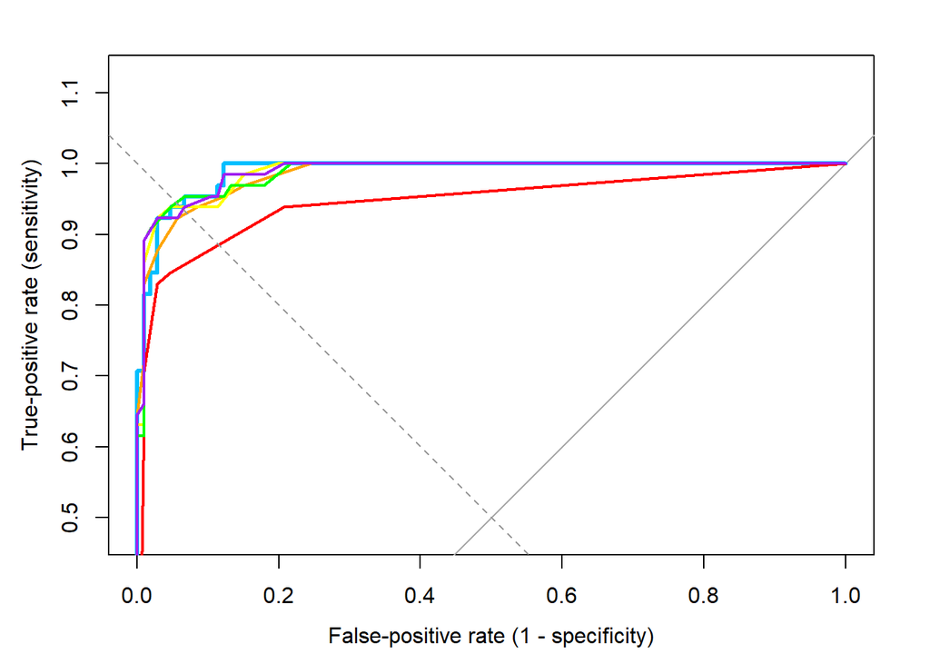

```r
roc_glm = roc(test_df$y, p_hat, levels = c(0,1), direction = "<")
plot(roc_glm, type = "l", col = "deepskyblue", lwd = 3,legacy.axes = TRUE,
     xlim = c(1, 0), ylim = c(0.6, 1), asp = 1,
     xlab = "False-positive rate (1 - specificity)",
     ylab = "True-positive rate (sensitivity)")
lines(roc5, col = "red")
lines(roc15, col = "orange")
lines(roc25, col = "yellow")
lines(roc35, col = "green")
lines(roc45, col = "purple")
abline(0, 1, col = "gray60", lty = 2)
```

```r
auc(roc_glm)
```

```
Area under the curve: 0.989
```

```r
auc(roc5)
```

```
Area under the curve: 0.9446
```

```r
auc(roc15)
```

```
Area under the curve: 0.9849
```

```r
auc(roc25)
```

```
Area under the curve: 0.9873
```

```r
auc(roc35)
```

```
Area under the curve: 0.9872
```

```r
auc(roc45)
```

```
Area under the curve: 0.9883
```

I chose the generalized linear model because it had a high area under the curve while also quickly reaching a high true positive rate. Since the data is about cancer patients, it would be really bad to not have a high true positive rate. It is also less complicated than the models with many k folds.

## Question 2: Training and test ROC curves

Use the same data, training/test split, and standardization as in Question 1. Fit KNN with Euclidean distance, equal neighbor weights, and

$$k\in\{1,3,5,10,20\}.$$

Use each fitted model to estimate probabilities for both the training and test observations. For training predictions, include each observation itself among its $k$ nearest neighbors.

For each $k$, use a separate panel to show the training and test ROC curves together. Report both AUC values.

Explain the difference between training and test performance and how it changes with $k$. In particular, explain what happens at $k=1$ and why training performance may not reflect performance on new observations.

```r
preds_testperformance = list()
ks = c(1, 3, 5, 10, 20)
for (k in ks)
{knn.fit = kknn(y ~ rad_center + text_center + smooth_center, train = train_df,
                test = test_df, k = k, kernel = "rectangular")

preds_testperformance[[paste0("KNN_", k)]] = knn.fit$prob[,2]}

preds_trainperformance = list()
ks = c(1, 3, 5, 10, 20)
for (k in ks)
{knn.fit = kknn(y ~ rad_center + text_center + smooth_center, train = train_df,
                test = train_df, k = k, kernel = "rectangular")

preds_trainperformance[[paste0("KNN_", k)]] = knn.fit$prob[,2]}
```

```r
roc1_test = roc(test_df$y, preds_testperformance[["KNN_1"]])
roc3_test = roc(test_df$y, preds_testperformance[["KNN_3"]])
roc5_test = roc(test_df$y, preds_testperformance[["KNN_5"]])
roc10_test = roc(test_df$y, preds_testperformance[["KNN_10"]])
roc20_test = roc(test_df$y, preds_testperformance[["KNN_20"]])
roc1_train = roc(train_df$y, preds_trainperformance[["KNN_1"]])
roc3_train = roc(train_df$y, preds_trainperformance[["KNN_3"]])
roc5_train = roc(train_df$y, preds_trainperformance[["KNN_5"]])
roc10_train = roc(train_df$y, preds_trainperformance[["KNN_10"]])
roc20_train = roc(train_df$y, preds_trainperformance[["KNN_20"]])
```

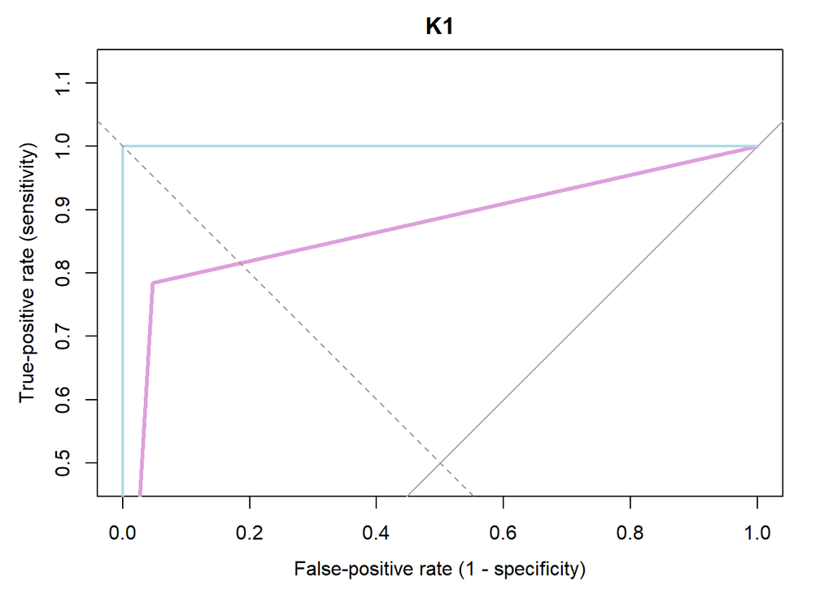

```r
plot(roc1_test, type = "l", col = "plum", lwd = 3,legacy.axes = TRUE,
     xlim = c(1, 0), ylim = c(0.6, 1), asp = 1,
     main = "K1",
     xlab = "False-positive rate (1 - specificity)",
     ylab = "True-positive rate (sensitivity)")
lines(roc1_train, col = "lightblue")
abline(0, 1, col = "gray60", lty = 2)
```

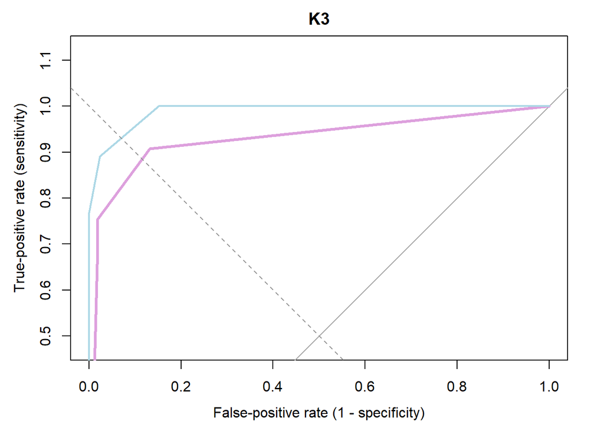

```r
plot(roc3_test, type = "l", col = "plum", lwd = 3,legacy.axes = TRUE,
     xlim = c(1, 0), ylim = c(0.6, 1), asp = 1,
     main = "K3",
     xlab = "False-positive rate (1 - specificity)",
     ylab = "True-positive rate (sensitivity)")
lines(roc3_train, col = "lightblue")
abline(0, 1, col = "gray60", lty = 2)
```

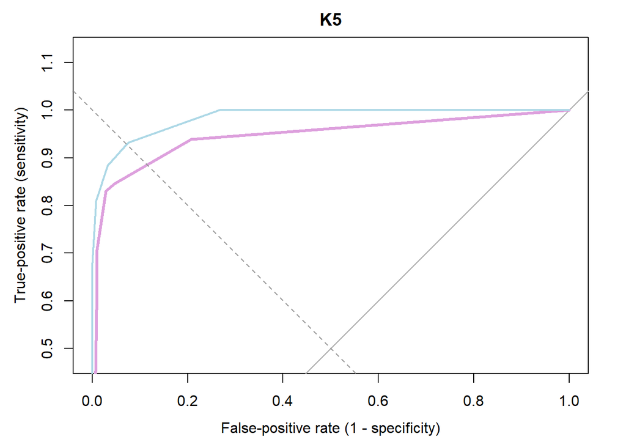

```r
plot(roc5_test, type = "l", col = "plum", lwd = 3,legacy.axes = TRUE,
     xlim = c(1, 0), ylim = c(0.6, 1), asp = 1,
     main = "K5",
     xlab = "False-positive rate (1 - specificity)",
     ylab = "True-positive rate (sensitivity)")
lines(roc5_train, col = "lightblue")
abline(0, 1, col = "gray60", lty = 2)
```

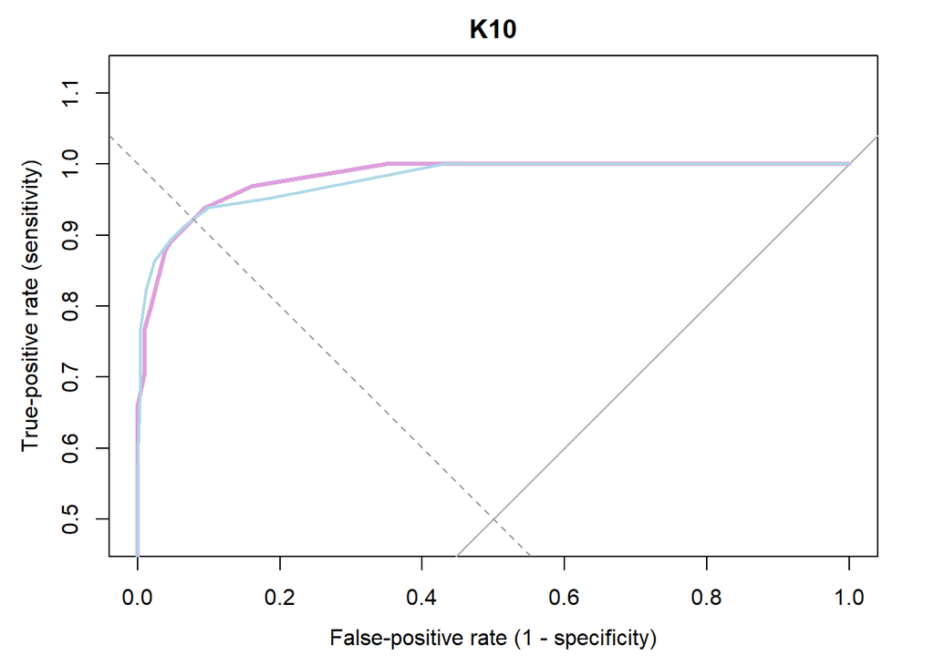

```r
plot(roc10_test, type = "l", col = "plum", lwd = 3,legacy.axes = TRUE,
     xlim = c(1, 0), ylim = c(0.6, 1), asp = 1,
     main = "K10",
     xlab = "False-positive rate (1 - specificity)",
     ylab = "True-positive rate (sensitivity)")
lines(roc10_train, col = "lightblue")
abline(0, 1, col = "gray60", lty = 2)
```

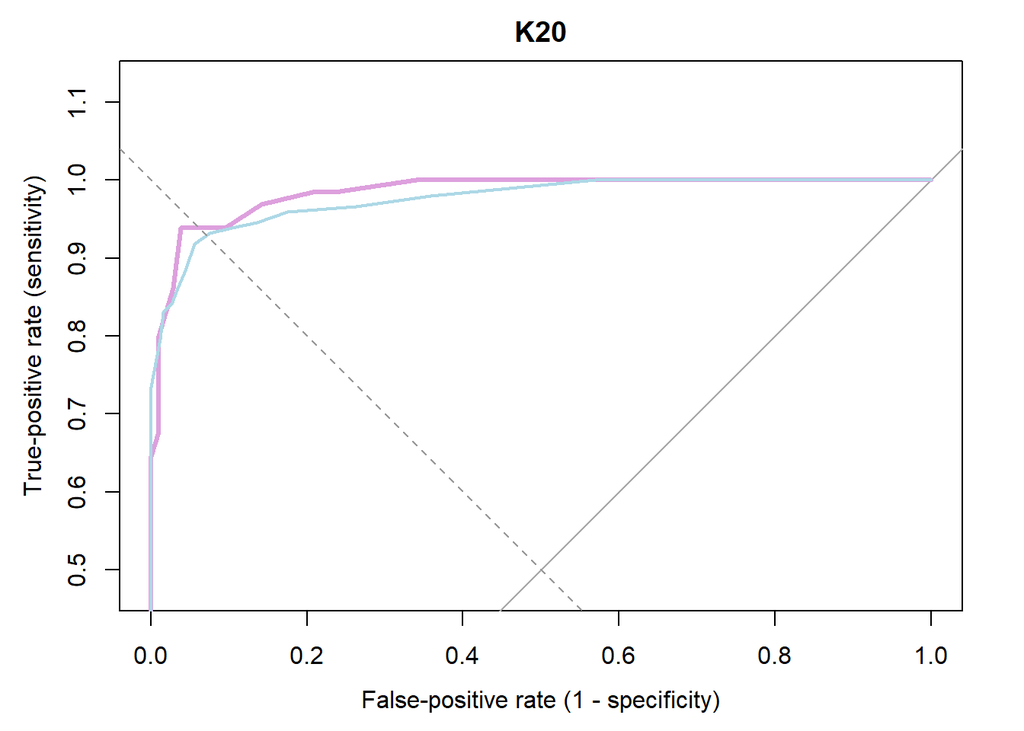

```r
plot(roc20_test, type = "l", col = "plum", lwd = 3,legacy.axes = TRUE,
     xlim = c(1, 0), ylim = c(0.6, 1), asp = 1,
     main = "K20",
     xlab = "False-positive rate (1 - specificity)",
     ylab = "True-positive rate (sensitivity)")
lines(roc20_train, col = "lightblue")
abline(0, 1, col = "gray60", lty = 2)
```

```r
data.frame("K Values" = c(1,3,5,10,20),
           "AUC for Training Data" = c(auc(roc1_train),auc(roc3_train), auc(roc5_train), auc(roc10_train), auc(roc20_train)),
           "AUC for Test Data" = c(auc(roc1_test),auc(roc3_test), auc(roc5_test), auc(roc10_test), auc(roc20_test)))
```

```
  K.Values AUC.for.Training.Data AUC.for.Test.Data
1        1             1.0000000         0.8687228
2        3             0.9889964         0.9284470
3        5             0.9837792         0.9445573
4       10             0.9774101         0.9809144
5       20             0.9761092         0.9842525
```

This table shows how for training performance, the AUC decreases as the number of k values increases, but for test performance, the AUC increases as the number of k values increases. This makes sense because increasing the number of k values allows us to see what the best number of k is to use so that we can find the best value to minimize prediction error and the bias variance tradeoff. So, for the training performance, we do not need to increase the number of k values because we have already predicted everything correctly since there is no testing data. This is why we have a AUC value of 1 for the training data with k = 1. However, since the model was built with only training data instead of test data, it has not been tested on new data, and therefore might not be the best performing on new data. This is also shown here because for the training data, we would choose k = 1, but we would likely choose a larger value of k for the testing data to have a larger area under the curve.

## Question 3: Peer evaluation of Homework 5

You will receive two Homework 5 submissions to review. The instructor’s GitHub account, **rqzhu-aide**, will open a **GitHub Issue** in the repository containing your Homework 5 submission. It will contain links to two other students’ repositories, where you can find their submitted homework reports.

Open your repository’s **Issues** tab on GitHub to find the assignment. You may ask AI to explain GitHub Issues or help you locate the assignment.

Choose **one specific mistake or item for improvement** from any question in either report.

1. **Identify the mistake or item for improvement.** State which report and question you selected, and briefly describe what is wrong or could be improved. Examples include incorrect code, a calculation error, a misinterpretation of results, a plot that could communicate the findings more clearly, or anything else you think could be done better.
2. **Explain your assessment.** Quote the relevant text, code, or figure caption exactly. Explain why the selected answer is incorrect or how it could be improved, referring to its reasoning, calculations, code, figures, or interpretation. **Complete this part yourself, without AI assistance.**
3. **Provide a correction.** Write a corrected or improved answer to the selected question, including any calculations, code, or figures needed.

After completing your review, **open a GitHub Issue in the repository containing the report you selected**. Identify the report and question, and include your assessment and a detailed revision plan explaining what the author should change and why. Include a link to your posted GitHub Issue in your Homework 6 answer.

The link to my posted issue is: https://github.com/conner-jensen/stat432-fall2026/issues/2.

This the comment I left, in case the link does not work:

Hi! I thought that your report was really good, and when I was going through and comparing it to the answer key, everything matched well. For Question 4 part c, you had everything correct, but one area that could be expanded upon even more would be the comparison between the two distance measures. You included the number of images that they had classified differently, but I thought the specific breakdown was interesting to visualize what was meant by the numbers they both missed. In the solution table, it shows how Manhattan got 11 wrong and Euclidean had 3 wrong, but then since that doesn’t add up to 22, it demonstrates how the other incorrectly classified images are “hidden”. Although it is just an extra detail, I think it would help to support your conclusion that “similar error rates therefore do not mean the same mistakes”. The provided code for that was:

```r
#table(Euclidean_correct = y_hat[, 1] == y_test,
      #Manhattan_correct = y_hat[, 2] == y_test)
```